# DWEI5_Aula02_Flask-TemplatesJinja

Instituto Federal de São Paulo (IFSP)  
[Campus Bragança Paulista/SP](https://bra.ifsp.edu.br)  
**Análise e Desenvolvimento de Sistemas (ADS)**  
**5o. módulo**  
**Profa. Ana Paula Müller Giancoli**  
paulagiancoli@ifsp.edu.br

## AULA 02 - MANIPULANDO TEMPLATES JINJA NO FLASK

### Agenda

- Apresentação JINJA
- Continuando a criação da estrutura organizacional do projeto
- Editando arquivos base.html
- Editando arquivos index.html
- Editando arquivo __init__.py
- Validando templates
- Perguntas

### 1.1. Apresentação JINJA

- De acordo com Gaspar, D. e Stouffer, J. em **Mastering Flask Web Development**, Jinja é uma linguagem de templates (modelos) escrita em Python.
- Uma linguagem de modelo é projetada em um formato simples para ajudar a automatizar a criação de documentos. Em qualquer linguagem de template, as variáveis passadas para o template substituem elementos predefinidos no template.
- No Jinja, as substituições de variáveis são definidas por **{{ variavel }}**. A sintaxe **{{ variavel }}** é chamada de **bloco variável**.
- Outro tipo de bloco, são os **blocos de controle** definidos por **{% controle %}** que declaram funções de linguagem, como loops ou instruções if.
- Exemplo:

```
<!-- Exemplo template base.html -->
<!DOCTYPE html>
<html>
<head>
    <title>
        {% block titulo %}
            Template Base
        {% endblock %}
    </title>
</head>
<body>
    <div>
       {% block conteudo %}

       {% endblock %}
    </div>
</body>
</html>

<!-- Exemplo de index.html -->
{% extends "base.html" %}

{% block titulo %}
    Template Index
{% endblock %}

{% block conteudo %}
    <h1> {{ title }} </h1>
    <ul>
    {% for usuario in usuarios %}
        <li><a href="{{ usuario.url }}">{{ usuario.apelido }}</a></li>
    {% endfor %}
    </ul>
{% endblock %}
```

### O que significa ?

```
<!-- Exemplo de index.html -->
<!-- Quando utilizamos extends e o nome do arquivo HTML entre aspas, estamos indicando ao Jinja
 para herdar o template base.html -->
{% extends "base.html" %}

<!-- Ao utilizarmos blocos, e identificarmos o bloco com o nome titulo. Para substituir o titulo
do template base.html, precisamos especificar desta forma. -->
{% block titulo %} Template Index {% endblock %}
{% block conteudo %} O que for escrito aqui substituirá o body do template base.html {% endblock %}
{{ title }} será substituído pelo conteúdo da variável title.
```

### 2. Continuando a criação da estrutura organizacional do projeto

- Crie uma pasta nomeada:
  - **projeto**.
- Dentro da pasta **projeto**, crie uma pasta nomeada:
  - **app**.
- Dentro da pasta **app**, crie as pastas:
  - **templates**.
- Dentro da pasta **templates**, crie dois arquivos com extensão html:
  - **base.html**.
  - **index.html**.
- Lembre de criar o ambiente virtual **venv** dentro da pasta **projeto**. Para isso, de dentro da pasta **projeto**, execute: **python3 -m venv venv**. (**Obs.**: Caso já tenha feito, não há necessidade de executar novamente, basta ativar o ambiente virtual.)
- Em seguida, inicie, ou melhor, ative o ambiente virtual **venv**, por meio: **source venv/bin/activate**, conforme seu SO.
- Faça a instalação do Flask. (**Obs.**: uma vez feita dentro do ambiente virtual, não é necessário a instalação novamente quando for utilizar o ambiente. Basta uma única vez.)
- Inicie o servidor flask executando de dentro da pasta **app**: **python3 __init__.py**. (**Obs**: esta execução é feita desta forma devido a criação do nosso arquivo inicial.)

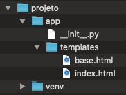

### 3. Editando arquivos base.html

```
<!-- arquivo templates/base.html -->
<!DOCTYPE html>
<html>

<head>
    <meta charset="utf-8">
    <meta http-equiv="X-UA-Compatible" content="IE=edge">
    <meta name="viewport" content="width=device-width, initial-scale=1">
    <title>
        {% block titulo %}
            Primeiro App Flask  ----> poderá ser substituído quando usarem o block titulo.
        {% endblock titulo %}
    </title>
    <!-- Script para imprimir relatório em pdf -->
    <script src="https://cdnjs.cloudflare.com/ajax/libs/jspdf/1.4.1/jspdf.debug.js" integrity="sha384-THVO/sM0mFD9h7dfSndI6TS0PgAGavwKvB5hAxRRvc0o9cPLohB0wb/PTA7LdUHs" crossorigin="anonymous"></script>
    <!-- Script para plotar gráficos -->
    <script src="https://cdn.plot.ly/plotly-latest.min.js"></script>
    <!-- Link para o Bootstrap CDN -->
    <link href="https://cdn.jsdelivr.net/npm/bootstrap@5.0.0-beta2/dist/css/bootstrap.min.css" rel="stylesheet" integrity="sha384-BmbxuPwQa2lc/FVzBcNJ7UAyJxM6wuqIj61tLrc4wSX0szH/Ev+nYRRuWlolflfl" crossorigin="anonymous">

</head>

<body class="container-fluid">
    <section>
        <div>
            <nav class="navbar navbar-dark bg-primary">
                <div class="container-fluid">
                    <a class="navbar-brand" href="#">APP Flask</a>
                    <button class="navbar-toggler" type="button" data-bs-toggle="collapse" data-bs-target="#navbarText" aria-controls="navbarText" aria-expanded="false" aria-label="Toggle navigation">
                      <span class="navbar-toggler-icon"></span>
                    </button>
                    <div class="collapse navbar-collapse" id="navbarText">
                      <ul class="navbar-nav me-auto mb-2 mb-lg-0">
                        <li class="nav-item">
                          <a class="nav-link active" aria-current="page" href="#">Home</a>
                        </li>

                        <li class="nav-item">
                          <a class="nav-link" href="#">Perfil</a>
                        </li>
                        <li class="nav-item">
                          <a class="nav-link" href="#">Novo</a>
                        </li>
                        <li class="nav-item">
                            <a class="nav-link" href="#">Listagem</a>
                        </li>
                        <li class="nav-item">
                            <a class="nav-link" href="#">Gráficos</a>
                        </li>

                        <li class="nav-item">
                            <a class="nav-link" href="#">Acessar</a>
                        </li>
                        <li class="nav-item">
                            <a class="nav-link" href="#">Registrar</a>
                        </li>

                        <li class="nav-item">
                            <a class="nav-link" href="#">Sair</a>
                        </li>

                      </ul>

                    </div>
                </div>
            </nav>

        </div>
        <div class="container-fuid">
            <div class="container text-centered">
               {% block content %}    ----> poderá ser substituído quando usarem o block content.

               {% endblock %}
            </div>
        </div>
    </section>
    {% block script %}  ----> poderá ser substituído quando usarem o block script.

    {% endblock %}
    <!-- Option 2: Separate Popper and Bootstrap JS -->
    <script src="https://cdn.jsdelivr.net/npm/@popperjs/core@2.6.0/dist/umd/popper.min.js" integrity="sha384-KsvD1yqQ1/1+IA7gi3P0tyJcT3vR+NdBTt13hSJ2lnve8agRGXTTyNaBYmCR/Nwi" crossorigin="anonymous"></script>
    <script src="https://cdn.jsdelivr.net/npm/bootstrap@5.0.0-beta2/dist/js/bootstrap.min.js" integrity="sha384-nsg8ua9HAw1y0W1btsyWgBklPnCUAFLuTMS2G72MMONqmOymq585AcH49TLBQObG" crossorigin="anonymous"></script>

</body>

</html>
```

### 3. Editando arquivos index.html

```
{% extends "base.html" %}   ----> Herda do template base.html.

{% block titulo %}  ---> Substituindo a tag title.
    Primeira Página
{% endblock titulo %}

{% block content %}  ---> Substituindo o conteúdo do body.
    <h1 class="title">
        Primeiro App Flask
    </h1>
    <h2 class="subtitle">
        Teste de envio!!
    </h2>
{% endblock %}
```

### 4. Editando o arquivo __init__.py

- Os modelos de renderização são criados pelo Flask por meio do mecanismo de templates Jinja para gerar os arquivos html.
- Para renderizar, utilize:
  - **render_template("nometemplate.html", variavel=variavelpassada, ..., ...)**
  - Pode conter quantas variáveis forem necessárias para renderizar o modelo ou não enviar nenhuma.

```
# Importando o flask
from flask import Flask

# Para renderizar o template
from flask import render_template, request   <--------- Adicionado

# __name__ : indica o pacote onde a aplicacao esta.
app = Flask(__name__)

# Criando a primeira rota, no caso, a raiz da aplicacao
# Quando criamos rotas seguidas uma da outra, elas acessam a
# mesma requisicao HTTP.
@app.route("/")
@app.route("/index")

# Criamos uma funcao com mesmo nome da rota para manter padrao
# e facilitar o entendimento
def index():
    return render_template("index.html")     <--------- Modificado

# Verificamos se o arquivo app.py está sendo executado pelo terminal e,
# caso positivo, iniciamos o servidor do Flask.
if __name__ == "__main__":
    app.run()
```

### 5. Validando os templates

- Reinicie o servidor Flask. Para encerrar, no terminal, tecle: **ctrl+c**.
- Acesse a pasta **app**, e executamos:

```
python3 __init__.py
```

- O servidor flask será iniciado.

[figure not shown]

- Copie e cole no navegador: **http://127.0.0.1:5000/**

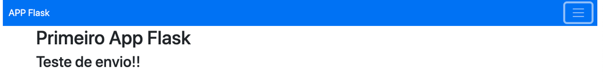

- Ao selecionar o menu recolhido, este é expandido para:

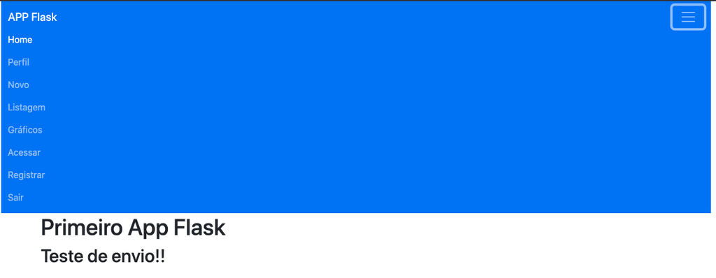

### ATENÇÃO

- **Lembre-se de encerrar o servidor ao final de cada aula**.
- **Lembre-se também, de desativar o ambiente virtual**.

### Referências

- Esta aula foi elaborada a partir do conteúdo disponibilizado em cada um dos links indicados no próprio texto.

### Perguntas

- Esclareça suas eventuais dúvidas durante as aulas.
- Ou pelo *E-mail*: paulagiancoli@ifsp.edu.br.
- Ou acesse [Github Ana Giancoli](https://anagiancoli.github.io) e solicite atendimento para o componente curricular.

*ADS - HTML5, CSS3, JS, FLASK - 5o. módulo*.  
Modelo e formato elaborado por profa. Ana Paula Müller Giancoli - BSD 2-Clause License. - Fevereiro.2021.